# els_0212

2026-02-04

# 0.R Markdown

# 1.Setup environment

## 0.1 Set working directory (Windows path: use forward slashes or double backslashes)

```r
#setwd("C:/Users/chy/Box/replication project_jj/data_stata")
```

## 0.2 Load data

```r
els <- readRDS("els_0212 2.rds")
```

# 1. Bookmark #1: Clean and define treatment variable

```r
treat_vars <- paste0("BYA38", LETTERS[1:16])  # BYA38A ... BYA38P
```

## 1.1 Prepare variables

```r
els <- els %>%
  # Create index (sum across all variables)
  mutate(sch_strict = rowSums(across(all_of(treat_vars)), na.rm = TRUE)) %>%
  # Quartiles (like xtile, nq(4))
  mutate(qrt_sch_strict = ntile(sch_strict, 4))
```

```r
# Binary below vs above median
med <- median(els$sch_strict, na.rm = TRUE)

els <- els %>%
  mutate(
    bi_sch_str = case_when(
      sch_strict <= med ~ 0,   # lower half
      sch_strict >  med ~ 1,   # upper half
      TRUE ~ NA_real_
    )
  )
```

Take a look at the sch_strict

```r
summary(els$sch_strict)
```

```
##    Min. 1st Qu.  Median    Mean 3rd Qu.    Max.
##   0.000   4.000   6.000   5.636   7.000  13.000
```

# 2. Bookmark #2: Outcomes

# 3. Bookmark #3: Selection vars

```r
byf_vars <- paste0("BYF09", LETTERS[1:5])  # BYF09A ... BYF09E
byp_vars <- c("BYP67", "BYP68")
```

# 4. Bookmark #4: Variables that used construct weight

mnps_q, ps_cont_fit will be defined later.

# 5. Bookmark #5: Selection models + weight visualizations (Twang)

```r
## convert to data.frame
els <- els %>% as.data.frame()
```

```r
# Check structure
class(els)
```

```
## [1] "data.frame"
```

Define covariates you want in the selection models

```r
# (Selection vars)
selvars <- c("litter_sch", "graffiti", "boardup_build", "congregate",
             "loiter", "crime", "safe_neigh")

# (Covariates: BYSEX, new_BYRACE, BYSES1, BYURBAN, BYP46, BYP49, BYS67, new_BYFCOMP)
covars <- c(
  "sex",
  "race",
  "ses_comp",
  "urban",
  "held_back",
  "disability",
  "eng_native",
  "fam_comp"
)
```

This function creates a histogram showing the distribution of weights, with separate panels for different treatment groups.

```r
plot_weight_dist <- function(dat, w_col, treat_col, title_txt = "") {
  p <- ggplot(dat, aes(x = .data[[w_col]])) +
    geom_histogram(bins = 60) +
    facet_wrap(vars(.data[[treat_col]]), scales = "free_y") +
    labs(title = title_txt, x = "Weight", y = "Count")

  print(p)
  invisible(p)
}
```

Here’s what each line does:

**Function definition** plot_weight_dist <- function(dat, w_col, treat_col, title_txt = ““) { Defines a function named plot_weight_dist that takes four parameters: dat (your data), w_col (name of the weight column as a string), treat_col (name of the treatment column as a string), and an optional title_txt (defaults to an empty string).

**Create the plot object** p <- ggplot(dat, aes(x = .data[[w_col]])) + Initializes a ggplot with your data and maps the weight column to the x-axis. The .data[[w_col]] syntax allows you to reference column names stored as strings (useful for flexible function arguments).

**Add histogram layer** geom_histogram(bins = 60) + Draws a histogram with 60 bins to show the frequency distribution of weights.

**Create separate panels** facet_wrap(vars(.data[[treat_col]]), scales = “free_y”) + Splits the histogram into separate subplots for each treatment group. The scales = “free_y” lets each panel have its own y-axis range (useful when treatment groups have different sample sizes).

**Add labels** labs(title = title_txt, x = “Weight”, y = “Count”) Sets the plot title, x-axis label (“Weight”), and y-axis label (“Count”).

**Display and return** print(p) shows the plot in your console, while invisible(p) returns it invisibly so you can assign it to a variable without printing it twice. The closing } ends the function.

This is a simplified version of the previous function. Here’s what changed:

```r
# Helper: quick weight distribution plot
plot_weight_dist <- function(dat, w_col, treat_col, title_txt = "") {
  ggplot(dat, aes(x = .data[[w_col]])) +
    geom_histogram(bins = 60) +
    facet_wrap(vars(.data[[treat_col]]), scales = "free_y") +
    labs(
      title = title_txt,
      x = "Weight",
      y = "Count"
    )
}
```

Removed the intermediate variable assignment: Instead of p <- ggplot(…) followed by print(p) and invisible(p), the function now directly returns the ggplot object. In R, the last expression in a function is automatically returned, so you don’t need explicit return() statements or intermediate variables.

**Line-by-line breakdown** plot_weight_dist <- function(dat, w_col, treat_col, title_txt = ““) { Same function definition as before.

ggplot(dat, aes(x = .data[[w_col]])) + Creates the base plot with weight mapped to the x-axis.

geom_histogram(bins = 60) + Adds the histogram layer with 60 bins.

facet_wrap(vars(.data[[treat_col]]), scales = “free_y”) + Splits into separate panels by treatment group, each with its own y-axis scale. labs(title = title_txt, x = “Weight”, y = “Count”) Adds labels. Note: this is formatted across multiple lines for readability, but it’s still one function call.

**Key difference** This version is more concise and follows R best practices—it returns the plot object automatically without the overhead of storing it in a variable. When you call plot_weight_dist(mydata, “weight”, “treatment”), it will both display and return the plot, which you can then save or further modify if needed.

## 5.1 BINARY selection model (PS): bi_sch_str

```r
els_bin <- els %>%
  filter(!is.na(bi_sch_str)) %>%
  mutate(bi_sch_str = as.numeric(as.character(bi_sch_str))) %>%
  filter(bi_sch_str %in% c(0,1)) %>%
  as.data.frame()

# Sanity check (must show only 0 and 1)
table(els_bin$bi_sch_str, useNA = "ifany")
```

```
##
##    0    1
## 8597 4746
```

```r
str(els_bin$bi_sch_str)
```

```
##  num [1:13343] 0 0 0 0 0 0 0 0 0 0 ...
```

```r
set.seed(123)

ps_bin <- ps(
  formula = as.formula(paste("bi_sch_str ~", paste(selvars, collapse = " + "))),
  data    = els_bin,
  n.trees = 10000,
  interaction.depth = 2,
  shrinkage = 0.01,
  perm.test.iters = 0,
  stop.method = c("es.mean", "ks.max"),
  estimand = "ATE",
  verbose = FALSE
)
```

This code uses the `ps()` function (from the `twang` package) to estimate propensity scores using gradient boosting. Here’s what each line does:

**Set random seed:** `set.seed(123)` Ensures reproducible results by setting the random number generator seed. Any code you run after this will produce the same “random” results each time.

**Initialize propensity score estimation:** `ps_bin <- ps(` Starts the propensity score calculation and stores the result in `ps_bin`.

**Data:** `data = els_bin,` The dataset containing the treatment, outcome, and covariates.

**Cross-validation:** `perm.test.iters = 0,` — Number of permutation test iterations (0 means skip this step)

**Stopping rules:** `stop.method = c("es.mean", "ks.max"),` Uses two methods to determine the optimal number of trees: `es.mean` (standardized mean difference) and `ks.max` (Kolmogorov-Smirnov statistic).

**Causal estimand:** `estimand = "ATE",` — Estimates the Average Treatment Effect (ATE) rather than ATT (Average Treatment Effect on the Treated)

**Suppress output:** `verbose = FALSE` Prevents the function from printing iteration details to the console.

```r
# Get ATE weights (one set per stop.method; pick one)
w_bin <- twang::get.weights(ps_bin, stop.method = "es.mean")
# Make w_bin numberic variable
els_bin$w_bin <- as.numeric(w_bin)
```

Visualize weighting 1. built-in Twang plots

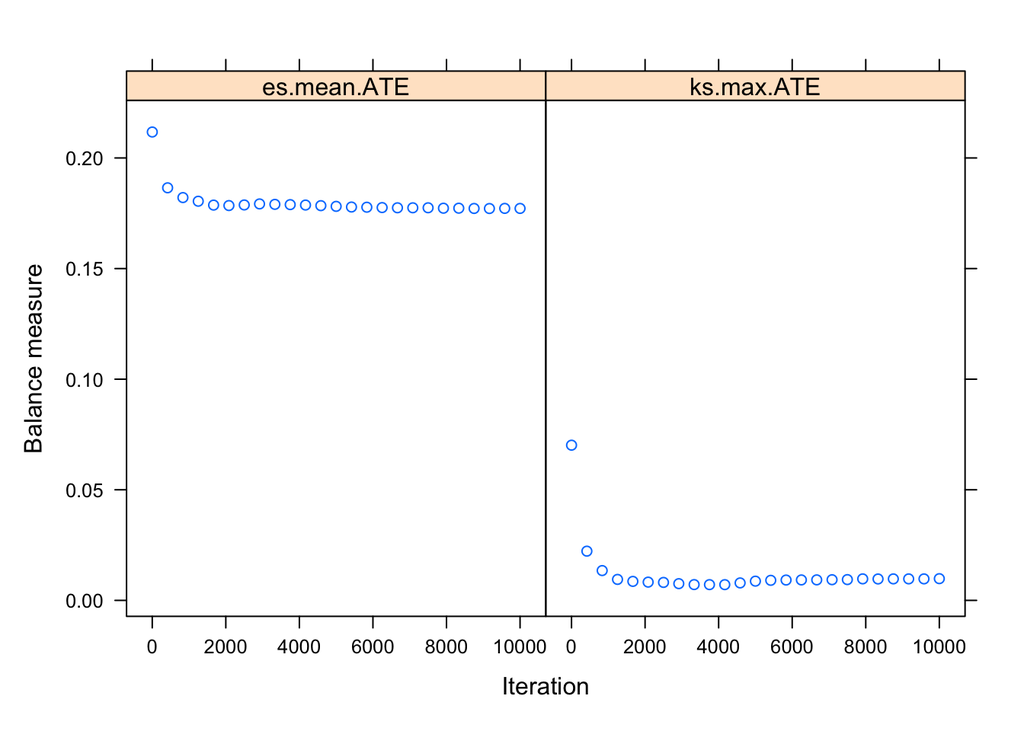

```r
# Common useful plots: "boxplot" of propensity scores, "es" balance, "ks"
plot(ps_bin, plots = 1)  # propensity score distributions
```

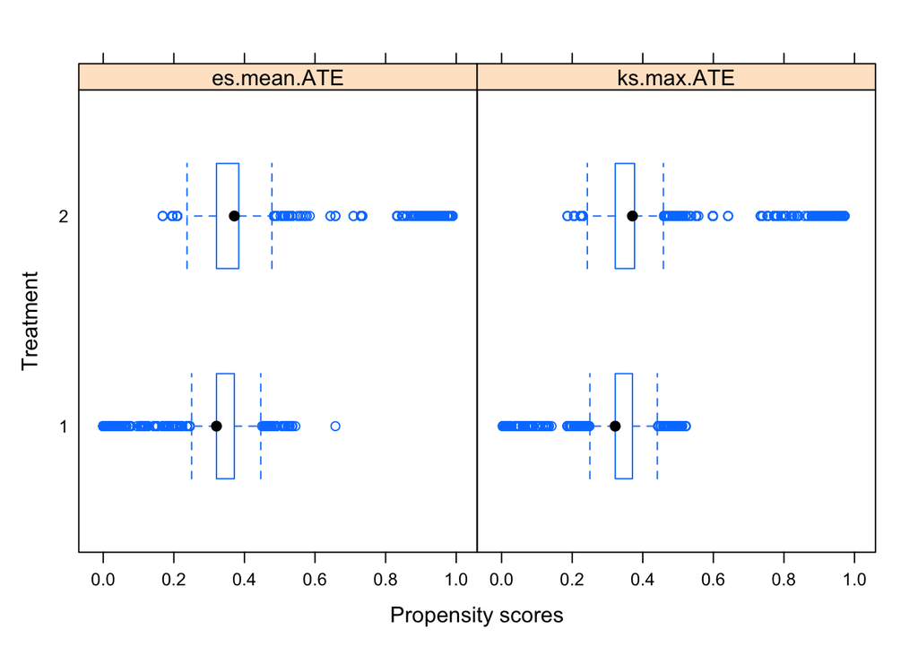

```r
plot(ps_bin, plots = 2)  # balance (ES) by stop methods
```

2.custom: weight distributions by treatment

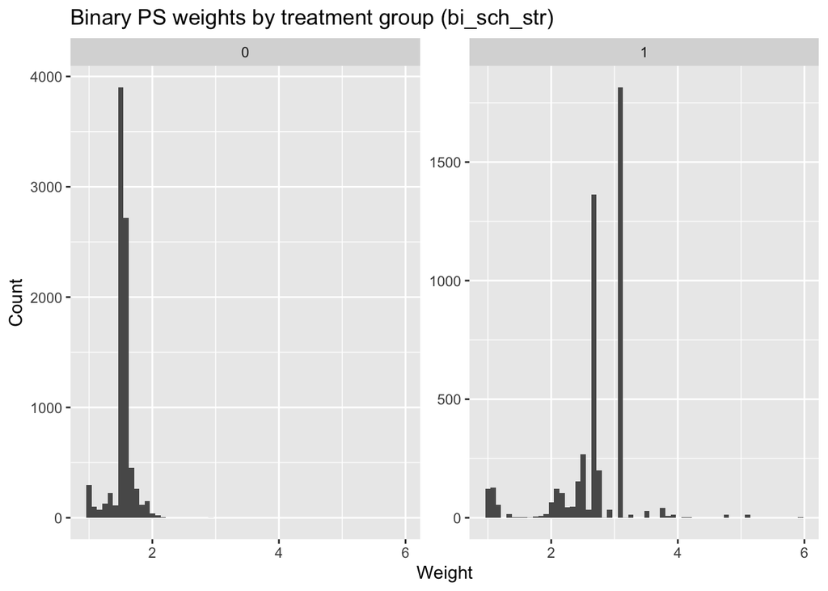

```r
print(plot_weight_dist(
  dat = els_bin,
  w_col = "w_bin",
  treat_col = "bi_sch_str",
  title_txt = "Binary PS weights by treatment group (bi_sch_str)"
))
```

3.(Optional) Visualize propensity score distribution by group

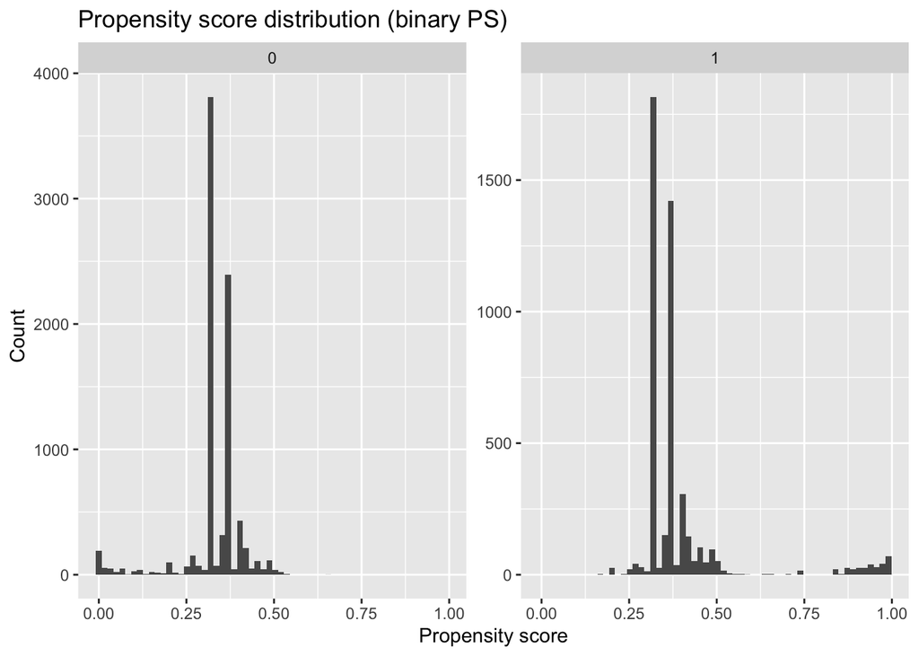

```r
els_bin$ps_hat <- ps_bin$ps$es.mean  # uses es.mean stop method fitted ps

ggplot(els_bin, aes(x = ps_hat)) +
  geom_histogram(bins = 60) +
  facet_wrap(~ bi_sch_str, scales = "free_y") +
  labs(title = "Propensity score distribution (binary PS)", x = "Propensity score", y = "Count")
```

## 5.2 MULTINOMIAL selection model (MNPS): qrt_sch_strict (4 groups)

```r
els_mn <- els %>%
  filter(!is.na(qrt_sch_strict)) %>%
  filter(if_all(all_of(covars), ~ !is.na(.x))) %>%
  mutate(qrt_sch_strict = factor(qrt_sch_strict, levels = 1:4)) %>%
  as.data.frame()                         # TWANG requires data.frame
```

```r
set.seed(123)

mnps_q <- mnps(
  formula        = as.formula(paste("qrt_sch_strict ~", paste(selvars, collapse = " + "))),
  data           = els_mn,
  n.trees        = 1000,
  interaction.depth = 2,
  shrinkage      = 0.01,
  perm.test.iters = 0,
  stop.method    = c("es.mean", "ks.max"),
  estimand       = "ATE",
  verbose        = FALSE
)
```

This code estimates propensity scores for a **multinomial treatment** (more than two treatment groups) using the `mnps()` function from the `twang` package. Here’s the breakdown:

**Initialize multinomial propensity score estimation:** `mnps_q <- mnps(` Starts the multinomial propensity score calculation and stores results in `mnps_q`. The key difference from `ps()` is that `mnps()` handles treatments with 3+ categories.

**Data:** `data = els_mn,` The dataset containing the treatment, outcome, and covariates.

**Cross-validation:** `perm.test.iters = 0,` — Skips permutation testing

**Stopping rules:** `stop.method = c("es.mean", "ks.max"),` Uses two criteria to find optimal number of trees: standardized mean difference and Kolmogorov-Smirnov statistic.

**Causal estimand:** `estimand = "ATE",` — Estimates Average Treatment Effect across all treatment group comparisons

**Suppress output:** `verbose = FALSE` Prevents iteration details from printing.

The main difference from the binary `ps()` example is that `mnps()` estimates propensity scores for each treatment group relative to the others, handling the multiway comparisons automatically.

```r
# Get ATE weights (choose stop.method)
w_mn <- twang::get.weights(mnps_q, stop.method = "es.mean")
els_mn$w_mn <- as.numeric(w_mn)
```

Visualize weighting 1.built-in Twang plots

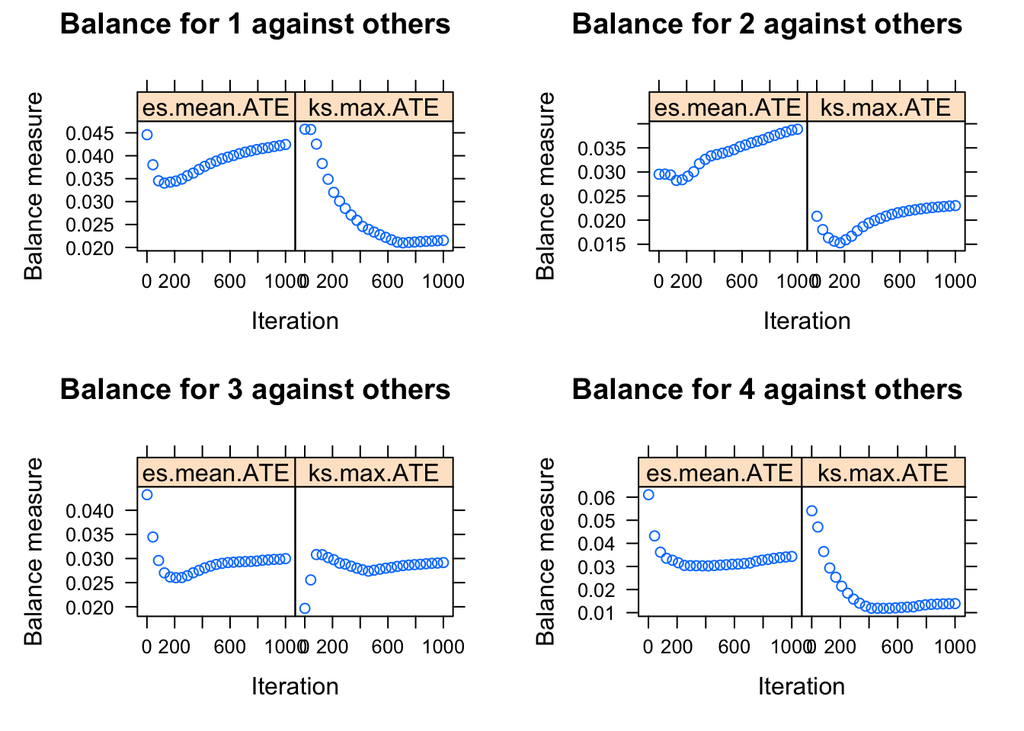

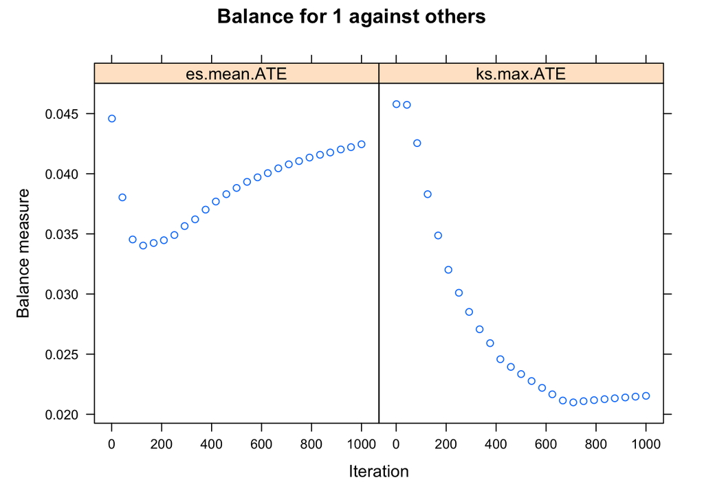

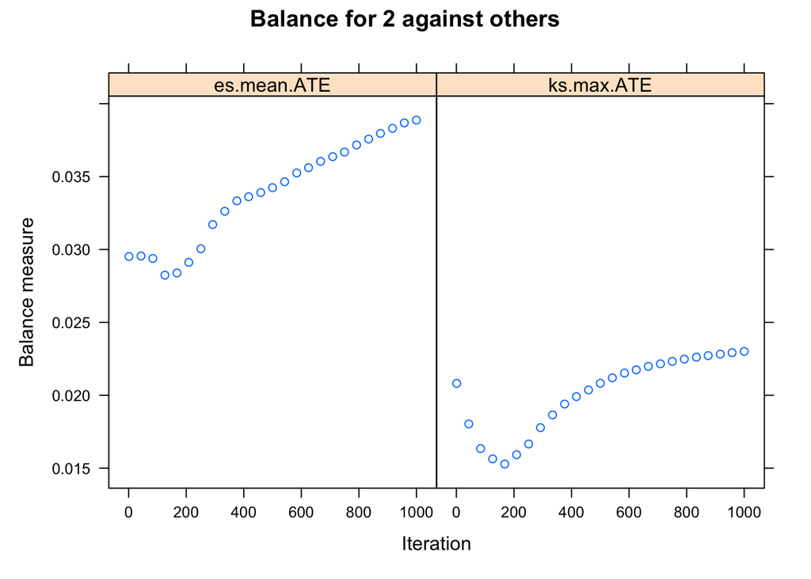

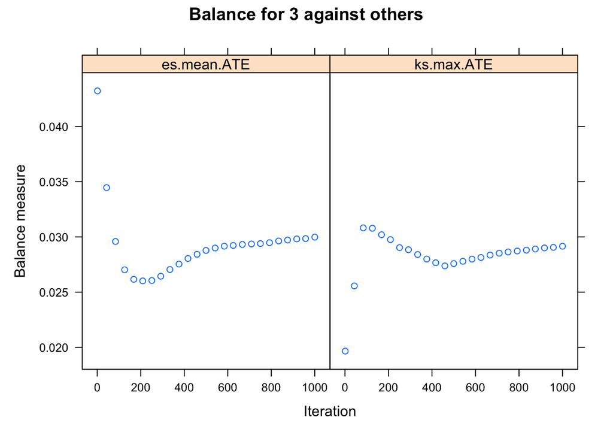

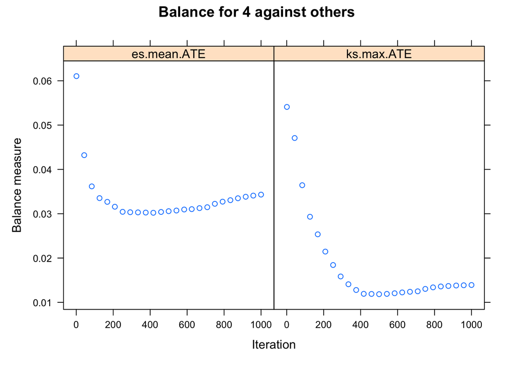

```r
plot(mnps_q, plots = 1)  # generalized PS distributions
```

[figure not shown]

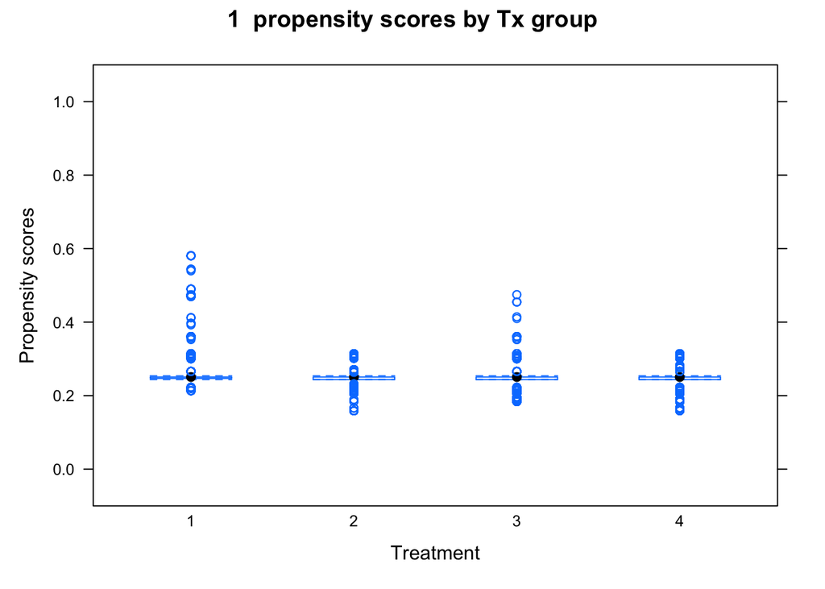

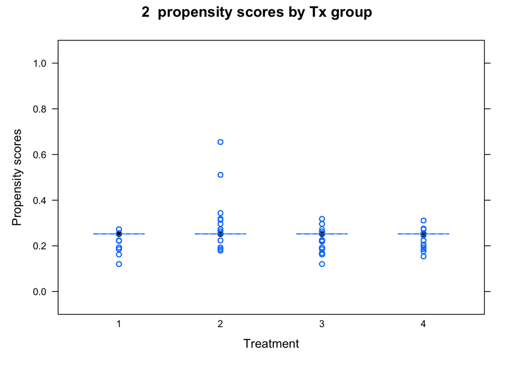

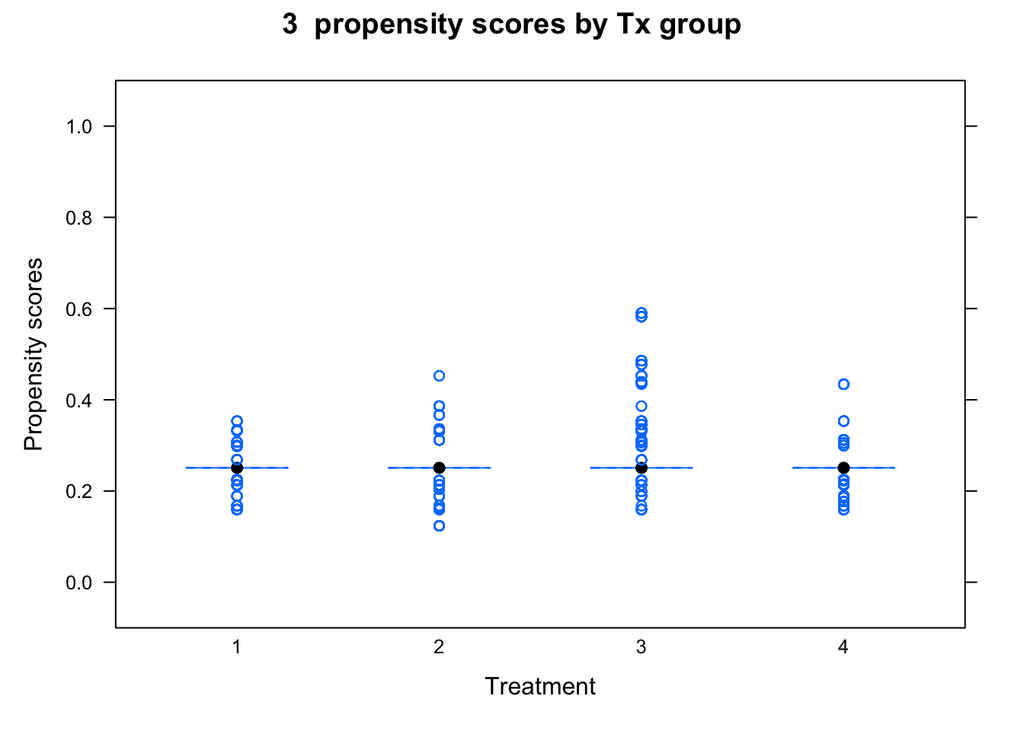

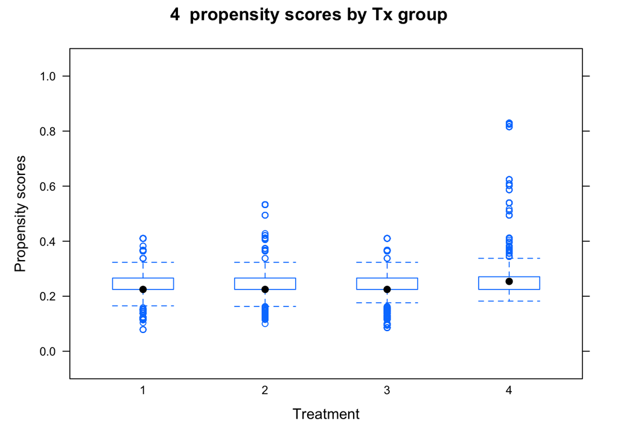

```r
plot(mnps_q, plots = 2)  # balance (ES) plot
```

2. custom: weight distributions by quartile

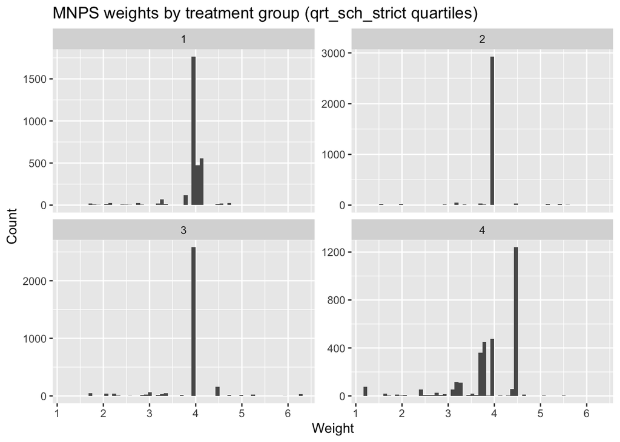

```r
print(plot_weight_dist(
  dat = els_mn,
  w_col = "w_mn",
  treat_col = "qrt_sch_strict",
  title_txt = "MNPS weights by treatment group (qrt_sch_strict quartiles)"
))
```

## 5.3 CONTINUOUS selection model (PS.CONT): sch_strict (0–13)

```r
model_vars <- c("sch_strict", selvars, covars, "math_score", "insch_sus", "times_sus")

els_cont <- els %>%
  select(all_of(model_vars)) %>%
  filter(complete.cases(.)) %>%
  as.data.frame()
```

```r
set.seed(123)

ps_cont_fit <- ps.cont(
  formula        = as.formula(paste("sch_strict ~", paste(selvars, collapse = " + "))),
  data           = els_cont,
  n.trees        = 5000,
  interaction.depth = 2,
  shrinkage      = 0.01,
  perm.test.iters = 0,
  stop.method    = c("es.mean", "ks.max"),
  verbose        = FALSE
)
```

This code estimates propensity scores for a **continuous treatment** using the `ps.cont()` function from the `twang` package. Here’s what each parameter does:

**Initialize continuous propensity score estimation:** `ps_cont_fit <- ps.cont(` Starts the continuous propensity score calculation and stores results in `ps_cont_fit`. Unlike `ps()` (binary) and `mnps()` (multinomial), `ps.cont()` handles treatments that are measured on a continuous scale.

**Data:** `data = els_cont,` The dataset containing the continuous treatment, outcome, and covariates.

**Boosting parameters:** `n.trees = 5000,` — Maximum number of trees to grow `interaction.depth = 2,` — Tree depth allowing two-way interactions `shrinkage = 0.01,` — Learning rate controlling the step size in boosting

**Cross-validation:** `perm.test.iters = 0,` — Skips permutation testing

**Stopping rules:** `stop.method = c("es.mean", "ks.max"),` Uses two criteria to determine optimal trees: standardized mean difference and Kolmogorov-Smirnov statistic (measuring covariate balance).

**Suppress output:** `verbose = FALSE` Prevents iteration details from printing to the console.

**Key difference from binary/multinomial:** `ps.cont()` models the continuous treatment as an outcome rather than estimating probabilities of group membership, making it suitable for dose-response or continuous exposure analyses.

```r
#Get continuous-treatment weights (choose stop.method)
w_cont <- ps_cont_fit$w

els_cont$w_cont <- as.numeric(w_cont)
```

Visualize weighting 1.custom: weight distribution overall + by binned sch_strict

```r
els_cont <- els_cont %>%
  mutate(
    sch_strict_bin = factor(
      ntile(sch_strict, 4),
      labels = c("Q1 (Low)", "Q2", "Q3", "Q4 (High)")
    )
  )
```

2. Overall weight distribution

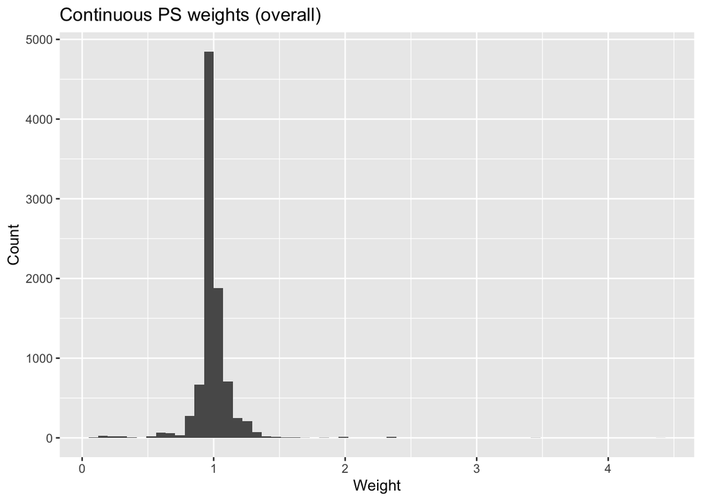

```r
ggplot(els_cont, aes(x = w_cont)) +
  geom_histogram(bins = 60) +
  labs(
    title = "Continuous PS weights (overall)",
    x = "Weight",
    y = "Count"
  )
```

3. By binned treatment

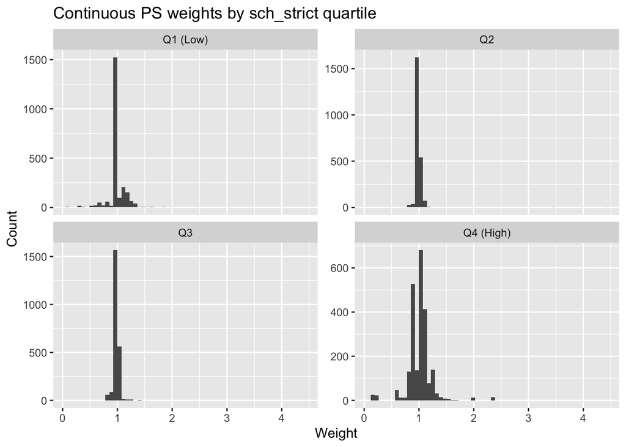

```r
plot_weight_dist(
  dat        = els_cont,
  w_col      = "w_cont",
  treat_col  = "sch_strict_bin",
  title_txt  = "Continuous PS weights by sch_strict quartile"
)
```

# 6. Bookmark #6: Outcome models for EACH outcome

**Structure per outcome** 1) Outcome = Treatment 2) Outcome = Treatment + Controls 3) Outcome = Treatment (PSWT) 4) Outcome = Treatment + Controls (PSWT)

```r
# Outcomes to run (continuous vs binary)
outcomes <- list(
  math_score = "continuous",
  insch_sus = "binary",
  times_sus = "binary"
)
```

Controls to use in weighted + controls models

```r
# (re-uses the same covars vector you defined above)
controls <- covars
```

Helper: fit the 4-model set for one outcome/treatment/weights

```r
fit_outcome_set <- function(dat, outcome, outcome_type, treat, w_col, controls) {

  # Keep complete cases needed for the 4 models
  keep_vars <- unique(c(outcome, treat, w_col, controls))
  d <- dat %>%
    dplyr::select(dplyr::all_of(keep_vars)) %>%
    dplyr::filter(!is.na(.data[[outcome]]), !is.na(.data[[treat]])) %>%
    dplyr::filter(dplyr::if_all(dplyr::all_of(controls), ~ !is.na(.x))) %>%
    as.data.frame()

  f1 <- as.formula(paste(outcome, "~", treat))
  f3 <- as.formula(paste(outcome, "~", treat, "+", paste(controls, collapse = " + ")))

  if (outcome_type == "continuous") {
    m1 <- lm(f1, data = d)
    m2 <- lm(f3, data = d)
    m3 <- lm(f1, data = d, weights = d[[w_col]])
    m4 <- lm(f3, data = d, weights = d[[w_col]])
  } else if (outcome_type == "binary") {
    # expects outcome coded 0/1
    m1 <- glm(f1, data = d, family = binomial())
    m2 <- glm(f3, data = d, family = binomial())
    m3 <- glm(f1, data = d, family = binomial(), weights = d[[w_col]])
    m4 <- glm(f3, data = d, family = binomial(), weights = d[[w_col]])
  } else {
    stop("Unknown outcome_type: ", outcome_type)
  }

  list(
    N = nrow(d),
    model_unweighted = m1,
    model_col_unweighted = m2,
    model_pswt       = m3,
    model_pswt_ctrl  = m4
  )
}
```

**Function definition:** `fit_outcome_set <- function(dat, outcome, outcome_type, treat, w_col, controls) {` Takes a dataset, outcome variable name, outcome type (continuous or binary), treatment variable name, weights column name, and control variables.

**Prepare data:** `keep_vars <- unique(c(outcome, treat, w_col, controls))` Creates a list of all variables needed for analysis (avoiding duplicates with `unique()`).

`d <- dat %>% dplyr::select(dplyr::all_of(keep_vars)) %>%` Selects only the necessary variables from the dataset.

`dplyr::filter(!is.na(.data[[outcome]]), !is.na(.data[[treat]])) %>%` Removes rows with missing outcome or treatment values.

`dplyr::filter(dplyr::if_all(dplyr::all_of(controls), ~ !is.na(.x))) %>%` Removes rows with missing values in any control variable.

`as.data.frame()` Converts the cleaned data to a standard data frame.

**Create formulas:** `f1 <- as.formula(paste(outcome, "~", treat))` Creates a simple formula with just treatment: `outcome ~ treatment`

`f3 <- as.formula(paste(outcome, "~", treat, "+", paste(controls, collapse = " + ")))` Creates a full formula with treatment and controls: `outcome ~ treatment + control1 + control2 + ...`

**Fit continuous outcome models:** `if (outcome_type == "continuous") {` Checks if outcome is continuous.

`m1 <- lm(f1, data = d)` — Unweighted regression (naive estimate, no propensity score weighting)

`m2 <- lm(f3, data = d)` — Unweighted regression with control variables (naive estimate, no propensity score weighting)

`m3 <- lm(f1, data = d, weights = d[[w_col]])` — Weighted by propensity scores only

`m4 <- lm(f3, data = d, weights = d[[w_col]])` — Weighted by propensity scores with control variables

**Fit binary outcome models:** `} else if (outcome_type == "binary") {` Checks if outcome is binary.

`m1 <- glm(f1, data = d, family = binomial())` — Unweighted logistic regression

`m2 <- glm(f3, data = d, family = binomial())` — Unweighted logistic regression ith controls

`m3 <- glm(f1, data = d, family = binomial(), weights = d[[w_col]])` — Weighted logistic regression

`m4 <- glm(f3, data = d, family = binomial(), weights = d[[w_col]])` — Weighted logistic regression with controls

**Error handling:** `} else { stop("Unknown outcome_type: ", outcome_type) }` Throws an error if outcome type is neither continuous nor binary.

## 6.1 Binary treatment outcomes

```r
results_bin <- list()
for (o in names(outcomes)) {
  results_bin[[o]] <- fit_outcome_set(
    dat          = els_bin,
    outcome      = o,
    outcome_type = outcomes[[o]],
    treat        = "bi_sch_str",
    w_col        = "w_bin",
    controls     = controls
  )
}
# Print summaries (Binary)
cat("\n==============================\n")
cat("OUTCOME MODELS: Binary Treatment (bi_sch_str)\n")
```

```
## OUTCOME MODELS: Binary Treatment (bi_sch_str)
```

```r
cat("==============================\n")
for (o in names(results_bin)) {
  cat("\n--- Outcome:", o, "| N =", results_bin[[o]]$N, "---\n")
  cat("\n1) Outcome = Treatment\n");              print(summary(results_bin[[o]]$model_unweighted))
  cat("\n1) Outcome = Treatment + Controls\n");              print(summary(results_bin[[o]]$model_col_unweighted))
  cat("\n2) Outcome = Treatment (PSWT)\n");       print(summary(results_bin[[o]]$model_pswt))
  cat("\n3) Outcome = Treatment + Controls (PSWT)\n"); print(summary(results_bin[[o]]$model_pswt_ctrl))
}
```

```
##
## --- Outcome: math_score | N = 12655 ---
##
## 1) Outcome = Treatment
##
## Call:
## lm(formula = f1, data = d)
##
## Residuals:
##     Min      1Q  Median      3Q     Max
## -32.299  -6.619   0.231   6.971  35.001
##
## Coefficients:
##             Estimate Std. Error t value Pr(>|t|)
## (Intercept)  51.6787     0.1094  472.19   <2e-16 ***
## bi_sch_str   -2.1632     0.1837  -11.78   <2e-16 ***
## ---
## Signif. codes:  0 '***' 0.001 '**' 0.01 '*' 0.05 '.' 0.1 ' ' 1
##
## Residual standard error: 9.888 on 12653 degrees of freedom
## Multiple R-squared:  0.01084,    Adjusted R-squared:  0.01076
## F-statistic: 138.7 on 1 and 12653 DF,  p-value: < 2.2e-16
##
##
## 1) Outcome = Treatment + Controls
##
## Call:
## lm(formula = f3, data = d)
##
## Residuals:
##     Min      1Q  Median      3Q     Max
## -36.216  -5.725   0.191   6.105  35.537
##
## Coefficients:
##             Estimate Std. Error t value Pr(>|t|)
## (Intercept) 52.99291    0.43824 120.921  < 2e-16 ***
## bi_sch_str  -1.21061    0.16578  -7.303 2.99e-13 ***
## sex         -0.95471    0.15786  -6.048 1.51e-09 ***
## race         0.24702    0.04059   6.086 1.19e-09 ***
## ses_comp     5.34523    0.11052  48.364  < 2e-16 ***
```

[output cut: 250 more lines]

```
## urban       -0.064387   0.035864  -1.795  0.07260 .
## held_back    0.006351   0.021605   0.294  0.76877
## disability  -0.069610   0.021734  -3.203  0.00136 **
## eng_native  -0.033510   0.013834  -2.422  0.01542 *
## fam_comp     0.414235   0.053730   7.710 1.26e-14 ***
## ---
## Signif. codes:  0 '***' 0.001 '**' 0.01 '*' 0.05 '.' 0.1 ' ' 1
##
## (Dispersion parameter for binomial family taken to be 1)
##
##     Null deviance: 13051  on 12041  degrees of freedom
## Residual deviance: 12505  on 12032  degrees of freedom
## AIC: 12456
##
## Number of Fisher Scoring iterations: 5
```

## 6.2 Multinomial treatment outcomes

```r
results_mn <- list()
for (o in names(outcomes)) {
  results_mn[[o]] <- fit_outcome_set(
    dat          = els_mn,
    outcome      = o,
    outcome_type = outcomes[[o]],
    treat        = "qrt_sch_strict",
    w_col        = "w_mn",
    controls     = controls
  )
}
# Print summaries (MNPS)
cat("\n==============================\n")
cat("OUTCOME MODELS: Multinomial Treatment (qrt_sch_strict)\n")
```

```
## OUTCOME MODELS: Multinomial Treatment (qrt_sch_strict)
```

```r
cat("==============================\n")
for (o in names(results_mn)) {
  cat("\n--- Outcome:", o, "| N =", results_mn[[o]]$N, "---\n")
  cat("\n1) Outcome = Treatment\n");              print(summary(results_mn[[o]]$model_unweighted))
  cat("\n1) Outcome = Treatment + Controls\n");              print(summary(results_mn[[o]]$model_col_unweighted))
  cat("\n2) Outcome = Treatment (PSWT)\n");       print(summary(results_mn[[o]]$model_pswt))
  cat("\n3) Outcome = Treatment + Controls (PSWT)\n"); print(summary(results_mn[[o]]$model_pswt_ctrl))
}
```

```
##
## --- Outcome: math_score | N = 12655 ---
##
## 1) Outcome = Treatment
##
## Call:
## lm(formula = f1, data = d)
##
## Residuals:
##     Min      1Q  Median      3Q     Max
## -32.288  -6.595   0.249   6.993  35.012
##
## Coefficients:
##                 Estimate Std. Error t value Pr(>|t|)
## (Intercept)      52.4054     0.1755 298.556  < 2e-16 ***
## qrt_sch_strict2  -0.7375     0.2482  -2.971  0.00297 **
## qrt_sch_strict3  -2.2639     0.2483  -9.117  < 2e-16 ***
## qrt_sch_strict4  -2.9763     0.2481 -11.996  < 2e-16 ***
## ---
## Signif. codes:  0 '***' 0.001 '**' 0.01 '*' 0.05 '.' 0.1 ' ' 1
##
## Residual standard error: 9.872 on 12651 degrees of freedom
## Multiple R-squared:  0.01416,    Adjusted R-squared:  0.01392
## F-statistic: 60.56 on 3 and 12651 DF,  p-value: < 2.2e-16
##
##
## 1) Outcome = Treatment + Controls
##
## Call:
## lm(formula = f3, data = d)
##
## Residuals:
##     Min      1Q  Median      3Q     Max
## -36.149  -5.715   0.154   6.086  36.342
##
## Coefficients:
##                 Estimate Std. Error t value Pr(>|t|)
## (Intercept)     53.59310    0.46006 116.492  < 2e-16 ***
## qrt_sch_strict2 -0.57788    0.22332  -2.588  0.00967 **
## qrt_sch_strict3 -1.32821    0.22386  -5.933 3.05e-09 ***
```

[output cut: 274 more lines]

```
## urban           -0.042874   0.025285  -1.696 0.089957 .
## held_back       -0.018776   0.015481  -1.213 0.225192
## disability      -0.042931   0.015799  -2.717 0.006581 **
## eng_native      -0.029045   0.010075  -2.883 0.003939 **
## fam_comp         0.400618   0.038540  10.395  < 2e-16 ***
## ---
## Signif. codes:  0 '***' 0.001 '**' 0.01 '*' 0.05 '.' 0.1 ' ' 1
##
## (Dispersion parameter for binomial family taken to be 1)
##
##     Null deviance: 25880  on 12041  degrees of freedom
## Residual deviance: 24752  on 12030  degrees of freedom
## AIC: 24610
##
## Number of Fisher Scoring iterations: 5
```

## 6.3 Continuous treatment outcomes

```r
results_cont <- list()
for (o in names(outcomes)) {
  results_cont[[o]] <- fit_outcome_set(
    dat          = els_cont,
    outcome      = o,
    outcome_type = outcomes[[o]],
    treat        = "sch_strict",
    w_col        = "w_cont",
    controls     = controls
  )
}
# Print summaries (Continuous)
cat("\n==============================\n")
cat("OUTCOME MODELS: Continuous Treatment (sch_strict)\n")
```

```
## OUTCOME MODELS: Continuous Treatment (sch_strict)
```

```r
cat("==============================\n")
for (o in names(results_cont)) {
  cat("\n--- Outcome:", o, "| N =", results_cont[[o]]$N, "---\n")
  cat("\n1) Outcome = Treatment\n");              print(summary(results_cont[[o]]$model_unweighted))
  cat("\n1) Outcome = Treatment + Controls\n");              print(summary(results_cont[[o]]$model_col_unweighted))
  cat("\n2) Outcome = Treatment (PSWT)\n");       print(summary(results_cont[[o]]$model_pswt))
  cat("\n3) Outcome = Treatment + Controls (PSWT)\n"); print(summary(results_cont[[o]]$model_pswt_ctrl))
}
```

```
##
## --- Outcome: math_score | N = 9254 ---
##
## 1) Outcome = Treatment
##
## Call:
## lm(formula = f1, data = d)
##
## Residuals:
##     Min      1Q  Median      3Q     Max
## -32.669  -6.615   0.394   7.052  34.631
##
## Coefficients:
##             Estimate Std. Error t value Pr(>|t|)
## (Intercept) 54.66836    0.25815  211.77   <2e-16 ***
## sch_strict  -0.52390    0.04239  -12.36   <2e-16 ***
## ---
## Signif. codes:  0 '***' 0.001 '**' 0.01 '*' 0.05 '.' 0.1 ' ' 1
##
## Residual standard error: 9.851 on 9252 degrees of freedom
## Multiple R-squared:  0.01624,    Adjusted R-squared:  0.01613
## F-statistic: 152.7 on 1 and 9252 DF,  p-value: < 2.2e-16
##
##
## 1) Outcome = Treatment + Controls
##
## Call:
## lm(formula = f3, data = d)
##
## Residuals:
##     Min      1Q  Median      3Q     Max
## -36.636  -5.688   0.197   5.996  35.942
##
## Coefficients:
##             Estimate Std. Error t value Pr(>|t|)
## (Intercept) 55.37241    0.54681 101.264  < 2e-16 ***
## sch_strict  -0.28019    0.03796  -7.381 1.71e-13 ***
## sex         -1.14321    0.18189  -6.285 3.43e-10 ***
## race         0.19377    0.04967   3.901 9.65e-05 ***
## ses_comp     5.43144    0.12877  42.179  < 2e-16 ***
```

[output cut: 250 more lines]

```
## urban       -0.010613   0.060428  -0.176 0.860588
## held_back    0.394806   0.104395   3.782 0.000156 ***
## disability   0.212890   0.091731   2.321 0.020297 *
## eng_native  -0.007823   0.027066  -0.289 0.772555
## fam_comp     0.471026   0.092123   5.113 3.17e-07 ***
## ---
## Signif. codes:  0 '***' 0.001 '**' 0.01 '*' 0.05 '.' 0.1 ' ' 1
##
## (Dispersion parameter for binomial family taken to be 1)
##
##     Null deviance: 4589.9  on 9253  degrees of freedom
## Residual deviance: 4367.8  on 9244  degrees of freedom
## AIC: 4415
##
## Number of Fisher Scoring iterations: 6
```